# Ejercicio 1

```r
library(readr)
library(FactoMineR)
library(factoextra)
library(cluster)
library(ggplot2)
library(gridExtra)
```

# Ejercicio 1

**En este ejercicio usaremos la tabla de datos EjemploAlgoritmosRecomendación.csv, la cual contiene los promedios de evaluación de 100 personas que adquirieron los mismos productos o muy similares en la tienda AMAZON. La idea consiste en recomendar a un cliente los productos que ha comprado otra persona que pertenece al mismo clúster.**

Se carga la base de datos necesaria.

```r
datos_Amazon <- read.table('EjemploAlgoritmosRecomendacion.csv', header=TRUE, sep=';',dec=',',row.names=1)
```

- **a) Ejecute un Clustering Jerárquico con la distancia euclídea y la agregación del Salto Máximo, Salto Mínimo, Promedio y Ward. Guarde la tabla de datos en el archivo AlgoritmosRecomendación2.csv con el clúster al que pertenece cada individuo para el caso de la agregación de Ward usando 2 clústeres.**

**Clustering Jerárquico con agregación del Salto Máximo**

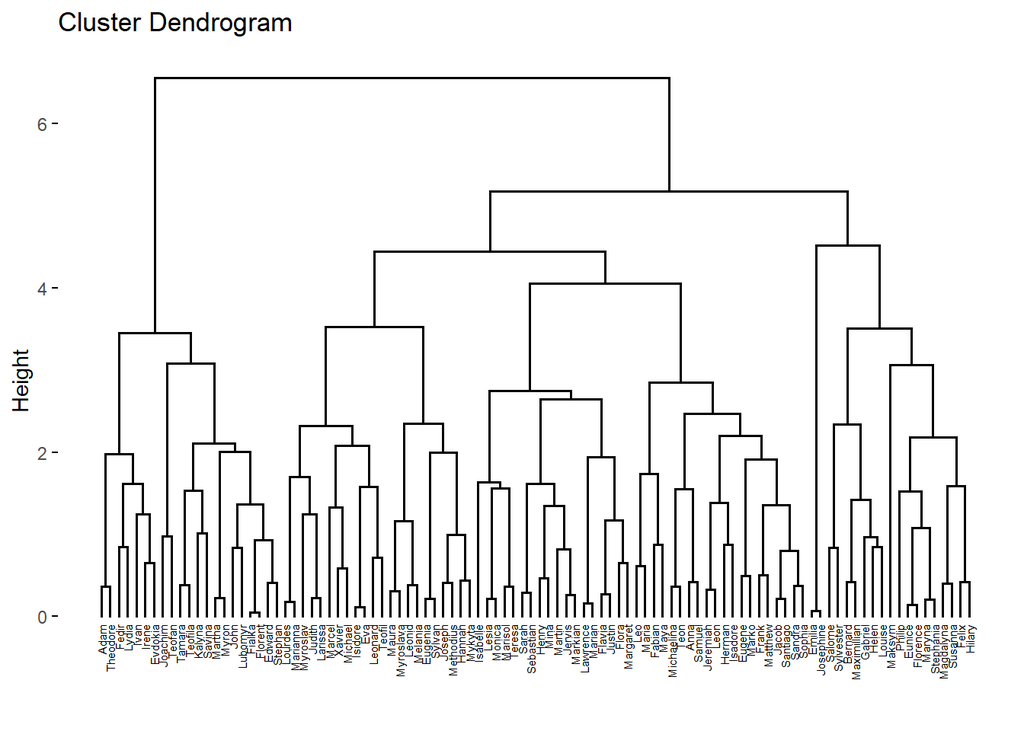

```r
clustering_SaltoMaximo<- hclust(dist(datos_Amazon), method = "complete")
fviz_dend(clustering_SaltoMaximo, cex = 0.4, repel = TRUE)
```

**Clustering Jerárquico con agregación del Salto Mínimo**

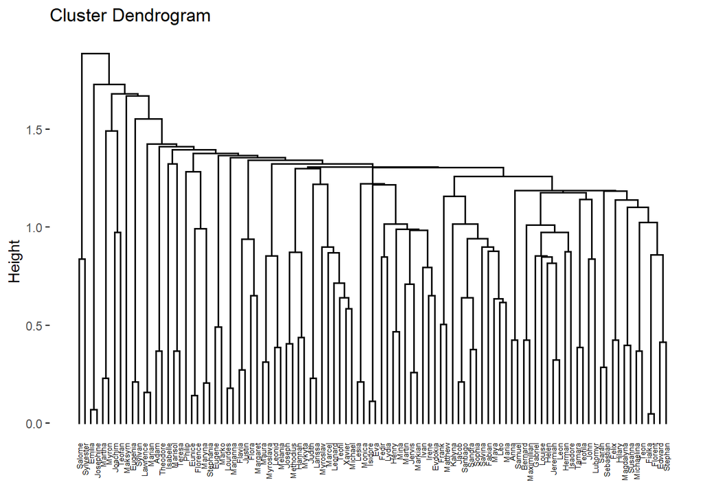

```r
clustering_SaltoMinimo <- hclust(dist(datos_Amazon), method = "single")
fviz_dend(clustering_SaltoMinimo, cex = 0.4, repel = TRUE)
```

**Clustering Jerárquico con agregación del Salto Promedio**

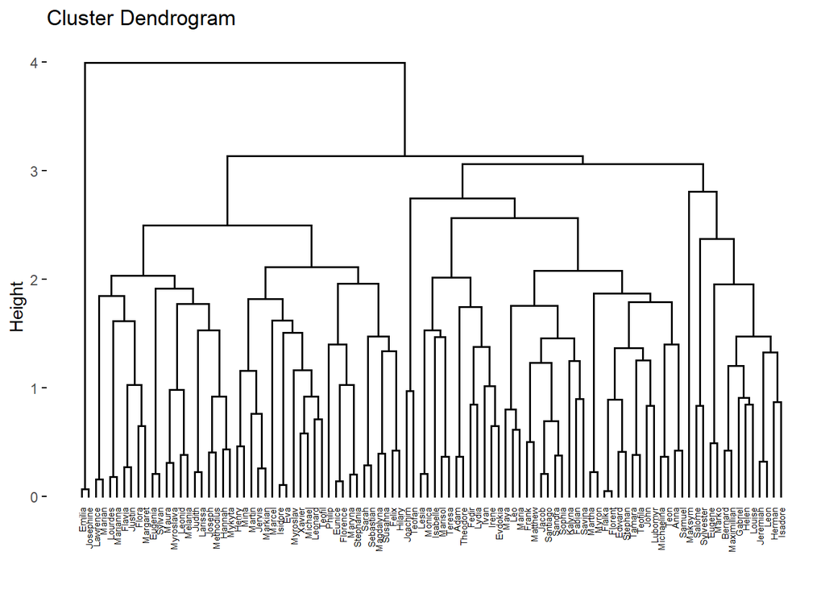

```r
clustering_SaltoPromedio <- hclust(dist(datos_Amazon), method = "average")
fviz_dend(clustering_SaltoPromedio, cex = 0.4, repel = TRUE)
```

**Clustering Jerárquico con agregación Ward**

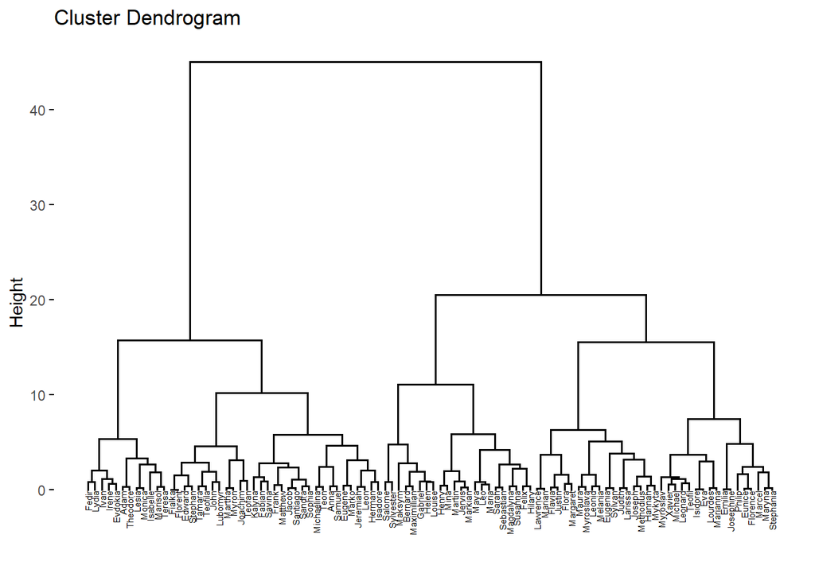

```r
clustering_Ward <- hclust(dist(datos_Amazon), method = "ward.D")
fviz_dend(clustering_Ward , cex = 0.4, repel = TRUE)
```

Ahora, usando el resultado obtenido por la agregación de Ward, se procede a guardar una tabla de datos con el clúster al que pertenece cada individuo usando 2 clústeres en el archivo AlgoritmosRecomendacion2.csv.

Primero, se añade la columna que indica el clúster al que pertenece cada individuo.

```r
Cluster <- cutree(clustering_Ward,k=2)
tabla_clusters_ward <- cbind(datos_Amazon,Cluster)
head(tabla_clusters_ward)
```

```
##         Velocidad.Entrega Precio Durabilidad Imagen.Producto Valor.Educativo
## Adam                 2.05   0.30        3.45            2.35             2.4
## Anna                 0.90   1.50        3.15            3.30             2.5
## Bernard              1.70   2.60        2.85            3.00             4.3
## Edward               1.35   0.50        3.55            2.95             1.8
## Emilia               3.00   0.45        4.80            3.90             3.4
## Fabian               0.95   1.65        3.95            2.40             2.6
##         Servicio.Retorno Tamano.Paquete Calidad.Producto Numero.Estrellas
## Adam                 2.3           2.60             2.10              1.7
## Anna                 4.0           4.20             2.15              2.8
## Bernard              2.7           4.10             2.60              3.3
## Edward               2.3           3.90             1.95              1.7
## Emilia               4.6           2.25             3.40              4.3
## Fabian               1.9           4.85             2.20              3.0
##         Cluster
## Adam          1
## Anna          1
## Bernard       2
## Edward        1
## Emilia        2
## Fabian        1
```

Después, se guarda en un nuevo documento csv.

```r
# Directorio
setwd("C:\\Users\\Caro\\OneDrive - Universidad de Costa Rica\\Escritorio\\Caro UCR\\I semestre 2024\\Análisis de datos\\tareas_analisis_i\\Tarea 8")

# Se guarda el archivo en como un CSV
write.csv(tabla_clusters_ward,"AlgoritmosRecomendacion2.csv")
```

- **b) “Corte” el árbol anterior usando 2 clústeres y la agregación de Ward, interprete los resultados usando gráficos de barras (Horizontal-Vertical) y usando gráficos tipo Radar.**

En el inciso a) se cortó el árbol usando 2 clústeres y la agregación de Ward, dicho corte se nombró `Cluster`.

**Interpretación**

A continuación, se realiza una interpretación de los clústeres mediante los centroides. Por lo tanto, es necesario encontrar el centroide de cada clúster.

De tal manera, se obtienen los centroides para cada clúster y se muestran sus coordenadas en el espacio de variables con la siguiente función:

```r
centroides_coord <- function(num.cluster, datos, clusters) {
  lista_centroides <- list()
  for(i in 1: num.cluster) {
    ind <- (clusters == i)
    centroide <- colMeans(datos[ind,])
    lista_centroides[[i]] <-  data.frame("Cluster" = i, "Variable" = names(centroide),
                              "Valor" = centroide)
  }
  return(lista_centroides)
}
```

Los centroides para cada clúster son

```r
centroides <- centroides_coord(2,datos_Amazon,Cluster)

for(i in 1:length(centroides)) {
  print(head(centroides[[i]]))
}
```

```
##                   Cluster          Variable    Valor
## Velocidad.Entrega       1 Velocidad.Entrega 1.262791
## Precio                  1            Precio 1.151163
## Durabilidad             1       Durabilidad 3.503488
## Imagen.Producto         1   Imagen.Producto 2.496512
## Valor.Educativo         1   Valor.Educativo 2.358140
## Servicio.Retorno        1  Servicio.Retorno 2.516279
##                   Cluster          Variable    Valor
## Velocidad.Entrega       2 Velocidad.Entrega 2.130702
## Precio                  2            Precio 1.205263
## Durabilidad             2       Durabilidad 4.281579
## Imagen.Producto         2   Imagen.Producto 2.720175
## Valor.Educativo         2   Valor.Educativo 3.336842
## Servicio.Retorno        2  Servicio.Retorno 2.777193
```

Seguidamente, se realizan los gráficos de barras para cada centroide.

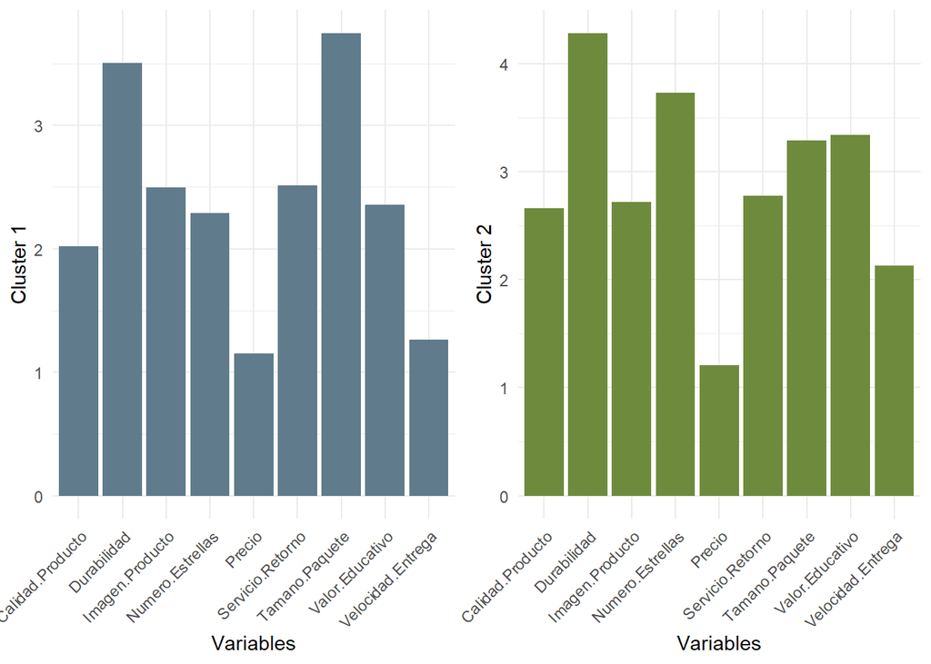

```r
# Se juntan los dataframes con las coordenadas de los centroides para cada clúster
centros <- do.call(rbind, centroides)
centros$Cluster <- as.factor(centros$Cluster)

# Se crean los gráficos de barra
barras1 <- ggplot(centros[centros$Cluster == "1", ], aes(x = Variable, y = Valor)) +
  geom_bar(stat = "identity", fill = "lightskyblue4") +
  labs(x = "Variables", y = "Cluster 1") +
  theme_minimal() +
  theme(axis.text.x = element_text(angle = 45, hjust = 1))

barras2 <- ggplot(centros[centros$Cluster == "2", ], aes(x = Variable, y = Valor)) +
  geom_bar(stat = "identity", fill = "darkolivegreen4") +
  labs(x = "Variables", y = "Cluster 2") +
  theme_minimal() +
  theme(axis.text.x = element_text(angle = 45, hjust = 1))

grid.arrange(barras1, barras2, ncol = 2)
```

De estos gráficos, se puede interpretar que las personas que se encuentran en el clúster 1 se inclinan a comprar un producto con un mejor tamaño de paquete y durabilidad. En cuanto al clúster 2, las personas prefieren la durabilidad seguido del número de estrellas que tiene el producto. En ambos clústeres, la característica con menor calificación es el precio.

También, se presenta un gráfico de tipo radar.

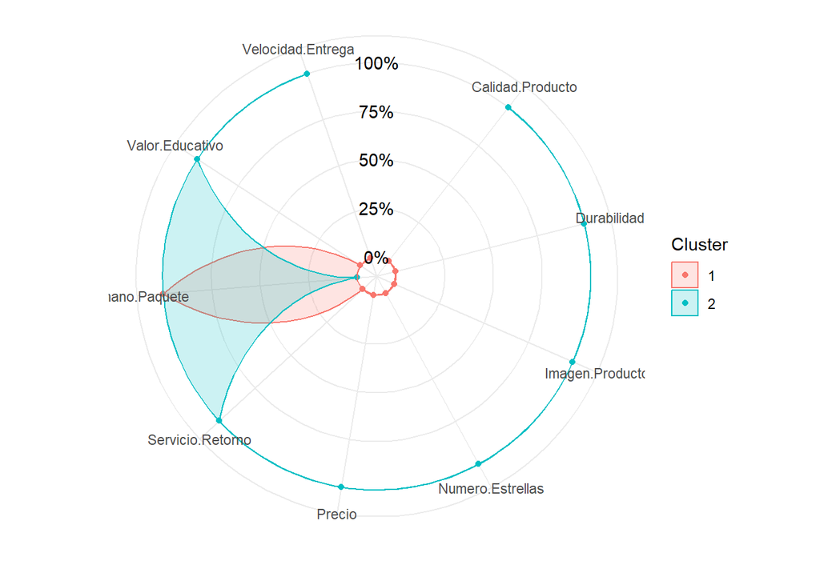

```r
for (x in unique(centros$Variable)) {
  aux <- centros[centros$Variable == x, "Valor"]
  aux <- aux - min(aux)
  aux <- aux / max(aux)
  centros[centros$Variable == x, "Valor"] <- aux
}

ggplot(data = centros[order(centros$Variable), ],
       aes(x = Variable, y = Valor, group = Cluster)) +
  geom_point(aes(colour = Cluster)) +
  geom_polygon(aes(colour = Cluster, fill = Cluster), alpha = 0.2) +
  ylim(-0.1, 1) + labs(x = "", y = "") + theme_minimal() +
  theme(axis.ticks.y = element_blank(), axis.text.y = element_blank()) +
  annotate('text', x = 0, y = c(0, 0.25, 0.5, 0.75, 1),
           label = c("0%", "25%", "50%", "75%", "100%"), color = "black") +
  coord_polar()
```

Se puede identificar que, las personas del clúster 1 se inclinan por productos con una buena calificación en el tamaño del paquete, como se mencionó anteriormente, pero malas calificaciones en las otras características. Con respecto al segundo clúster, se puede interpetrar que los clientes son más cautelesos con los productos que compran, pues, tienen buenas calificaciones en todas las características excepto, en el tamaño del paquete.

- **c) Si se tienen 4 clústeres usando agregación de Ward ¿Qué productos recomendaría a Teresa, a Leo y a Justin?, es decir, ¿los productos que compra cuál otro cliente? Usando distancia euclídea ¿cuál es la mejor recomendación de compra que le podemos hacer a Teresa, a Leo y a Justin?**

En este caso, el árbol que se obtuvo con distancia euclídea y agregación de Ward se “corta” en 4 clústeres.

```r
Cluster_2 <- cutree(clustering_Ward,k=4)
tabla_clusters_ward_2 <- cbind(datos_Amazon,Cluster_2)
head(tabla_clusters_ward_2)
```

```
##         Velocidad.Entrega Precio Durabilidad Imagen.Producto Valor.Educativo
## Adam                 2.05   0.30        3.45            2.35             2.4
## Anna                 0.90   1.50        3.15            3.30             2.5
## Bernard              1.70   2.60        2.85            3.00             4.3
## Edward               1.35   0.50        3.55            2.95             1.8
## Emilia               3.00   0.45        4.80            3.90             3.4
## Fabian               0.95   1.65        3.95            2.40             2.6
##         Servicio.Retorno Tamano.Paquete Calidad.Producto Numero.Estrellas
## Adam                 2.3           2.60             2.10              1.7
## Anna                 4.0           4.20             2.15              2.8
## Bernard              2.7           4.10             2.60              3.3
## Edward               2.3           3.90             1.95              1.7
## Emilia               4.6           2.25             3.40              4.3
## Fabian               1.9           4.85             2.20              3.0
##         Cluster_2
## Adam            1
## Anna            2
## Bernard         3
## Edward          2
## Emilia          4
## Fabian          2
```

Para responder a la pregunta, primeros se identifica el clúster al que pertenecen Teresa, Leo y Justin.

```r
# Encontrar el índice de la fila para Teresa, Leo y Justin
fila_idx_Teresa <- which(rownames(tabla_clusters_ward_2) == "Teresa")
fila_idx_Leo <- which(rownames(tabla_clusters_ward_2) == "Leo")
fila_idx_Justin <- which(rownames(tabla_clusters_ward_2) == "Justin")

col <- ncol(tabla_clusters_ward_2)
Teresa <- tabla_clusters_ward_2[fila_idx_Teresa, col]
Leo <- tabla_clusters_ward_2[fila_idx_Leo, col]
Justin <- tabla_clusters_ward_2[fila_idx_Justin, col]

num_cluster <- list("Teresa" = Teresa, "Leo" = Leo, "Justin" = Justin)
print(num_cluster)
```

```
## $Teresa
## [1] 1
##
## $Leo
## [1] 3
##
## $Justin
## [1] 4
```

Como se puede observar, Teresa se encuentra el clúster 1, Leo en el 3 y Justin en el 4.

A continuación, se presenta el siguiente radar que permite interpretar qué productos recomendar.

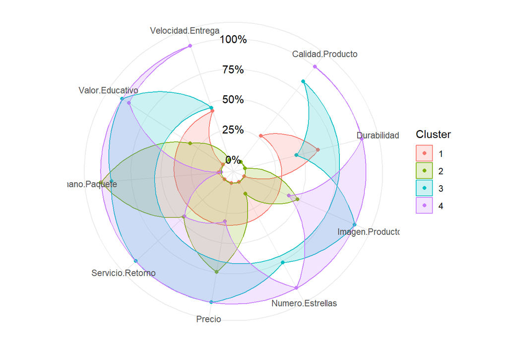

```r
# Centroides para cada clúster
centroides_2 <- centroides_coord(4,datos_Amazon,Cluster_2)

# Se juntan los dataframes con las coordenadas de los centroides para cada clúster
centros_2 <- do.call(rbind, centroides_2)
centros_2$Cluster <- as.factor(centros_2$Cluster)

# Se crea gráfico de radar
for (x in unique(centros_2$Variable)) {
  aux <- centros_2[centros_2$Variable == x, "Valor"]
  aux <- aux - min(aux)
  aux <- aux / max(aux)
  centros_2[centros_2$Variable == x, "Valor"] <- aux
}

ggplot(data = centros_2[order(centros_2$Variable), ],
       aes(x = Variable, y = Valor, group = Cluster)) +
  geom_point(aes(colour = Cluster)) +
  geom_polygon(aes(colour = Cluster, fill = Cluster), alpha = 0.2) +
  ylim(-0.1, 1) + labs(x = "", y = "") + theme_minimal() +
  theme(axis.ticks.y = element_blank(), axis.text.y = element_blank()) +
  annotate('text', x = 0, y = c(0, 0.25, 0.5, 0.75, 1),
           label = c("0%", "25%", "50%", "75%", "100%"), color = "black") +
  coord_polar()
```

Para el caso de Teresa, dado que se encuentra en el clúster 1, le interesan productos con una calificación medianamente buena en durabilidad y velocidad de entrega y muy bajas en las demás características, por lo que, se le recomienda comprar productos similares a los que adquieren las personas de este clúster, como es el caso de Adam según se muestra en la tabla `tabla_clusters_ward_2`.

En cuanto a Leo que se encuentra en el clúster 3, él se inclina por productos de buena calidad, con puntuaciones elevadas en valor educativo, tamaño del paquete, servicio de retorno, precio, imagen del producto y número de estrellas. Además, con calificaciones medianamente buenas en velocidad de entrega y durabilidad. Por tanto, se le sugiere adquirir productos iguales o similares a los comprados por otras personas de este clúster como por ejemplo, Bernard.

Finalmente, se identifica que Justin es más exigente en cuanto a la velocidad de entrega, calidad del producto, durabilidad y números de estrellas que los otros dos. Además, le gusta comprar por Amazon productos con muy buena puntación en valor educativo pero con calificaciones bajas-intermedias en precio, servicio de retorno e imagen del producto y el tamaño del paquete es la característica por la que menos se inclina. De tal manera, se le recomienda comprar productos parecidos a los que adquieren otras personas del clúster 4 como Emilia.

**d) Construya un clustering jerárquico sobre las componentes principales del ACP.**

Primeramente, se realiza el ACP sobre los datos para obtener las componentes principales.

```r
ACP <- PCA(datos_Amazon, graph = FALSE)
```

De tal manera,las componentes principales son:

```r
Componentes_principales <- ACP$ind$coord
head(Componentes_principales)
```

```
##              Dim.1      Dim.2      Dim.3       Dim.4       Dim.5
## Adam    -1.2796393 -1.6741953 -0.6854660 -1.60049107  0.62243565
## Anna    -1.1766366  2.3612555 -1.3902488 -0.04384467 -0.01154725
## Bernard  0.4534363  2.8950374  1.9397172 -0.70726560 -0.15560842
## Edward  -2.2995268 -0.4057411 -1.3872186 -0.18223265  0.53315142
## Emilia   4.5152653  0.2073306 -2.6930341 -0.84730823  0.01802200
## Fabian  -1.6079478  0.6623230  0.8863123  1.58603698 -0.21176844
```

Posteriormente, se realiza el clustering jerárquico sobre las componentes principales.

**Clustering Jerárquico con agregación del Salto Máximo**

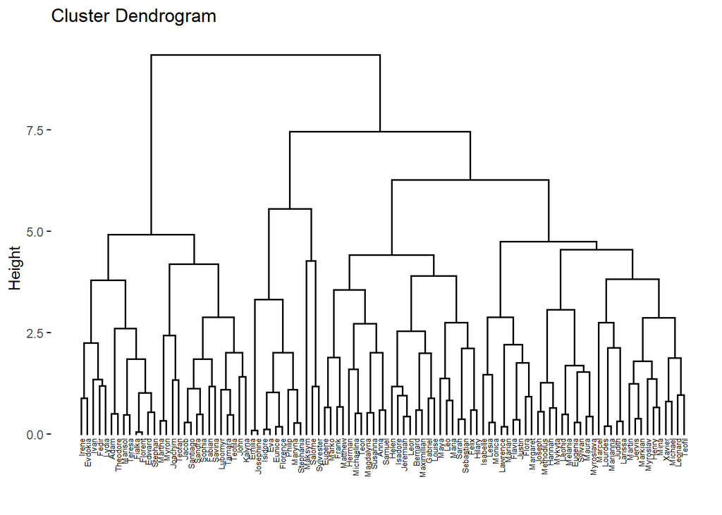

```r
clustering_SaltoMaximo_ACP<- hclust(dist(Componentes_principales), method = "complete")
fviz_dend(clustering_SaltoMaximo_ACP, cex = 0.4, repel = TRUE)
```

**Clustering Jerárquico con agregación del Salto Mínimo**

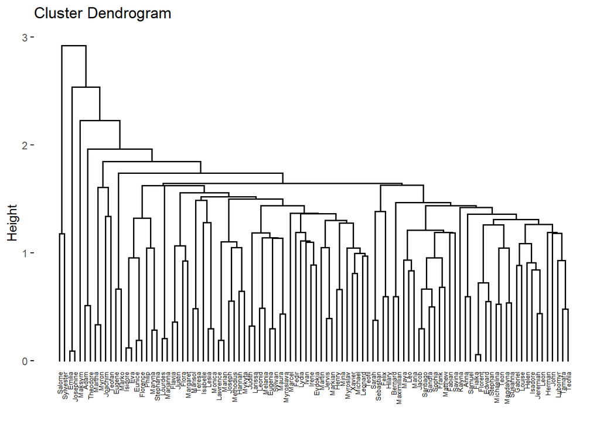

```r
clustering_SaltoMinimo_ACP <- hclust(dist(Componentes_principales), method = "single")
fviz_dend(clustering_SaltoMinimo_ACP, cex = 0.4, repel = TRUE)
```

**Clustering Jerárquico con agregación del Salto Promedio**

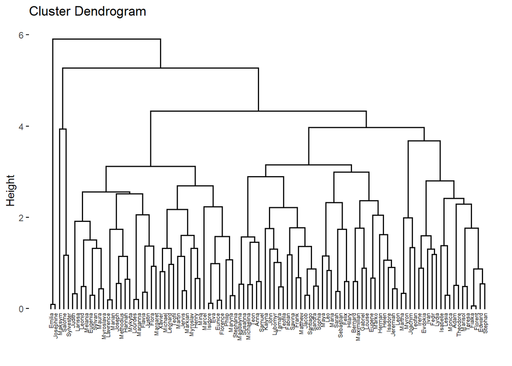

```r
clustering_SaltoPromedio_ACP <- hclust(dist(Componentes_principales), method = "average")
fviz_dend(clustering_SaltoPromedio_ACP, cex = 0.4, repel = TRUE)
```

**Clustering Jerárquico con agregación Ward**

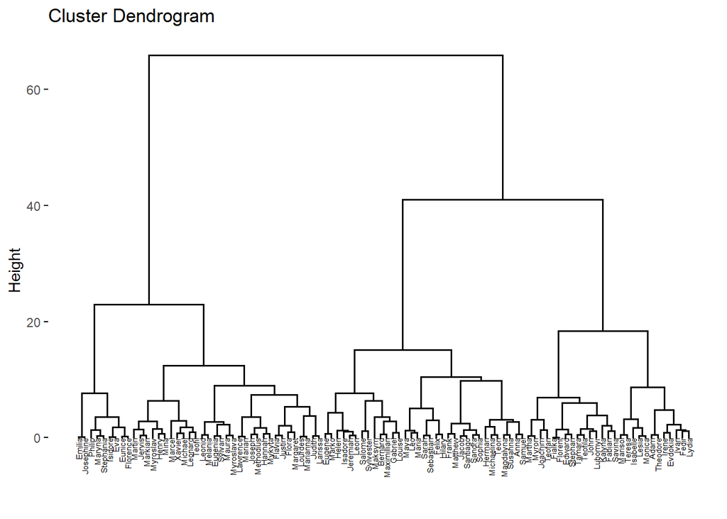

```r
clustering_Ward_ACP <- hclust(dist(Componentes_principales), method = "ward.D")
fviz_dend(clustering_Ward_ACP , cex = 0.4, repel = TRUE)
```